# Univariate Data

### Frequency polygons

Frequency polygon represent the histogram information in a different way. Rather than draw a rectangle for each bin, polygon puts a point at the top of the rectangle and then connect these points with straight lines.

One way to generate the polygon in R is to use the attributes of the histogram.

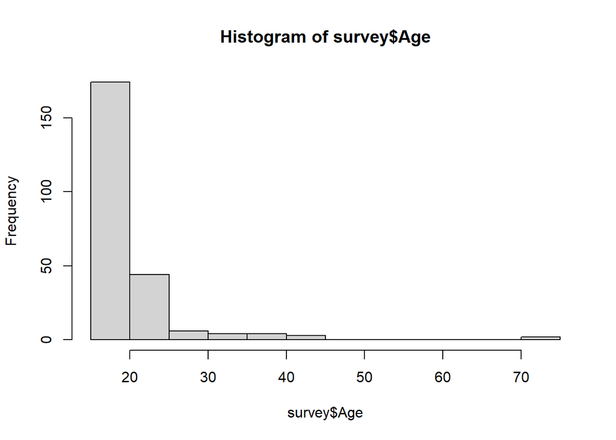

```r
> h <- hist(survey$Age)
```

```r
> attributes(h)
$names
[1] "breaks"   "counts"   "density"  "mids"     "xname"    "equidist"

$class
[1] "histogram"
```

Where `breaks` gives the histogram cells boundaries, `counts` gives the number observations in the bound, `mids` gives the histogram cell midpoints

```r
> h$breaks
 [1] 15 20 25 30 35 40 45 50 55 60 65 70 75
> h$counts
 [1] 174  44   6   4   4   3   0   0   0   0   0   2
> h$mids
 [1] 17.5 22.5 27.5 32.5 37.5 42.5 47.5 52.5 57.5 62.5 67.5 72.5
```

Using this data we can draw the polygon with the `line` function, giving its `x` and `y` coordinates

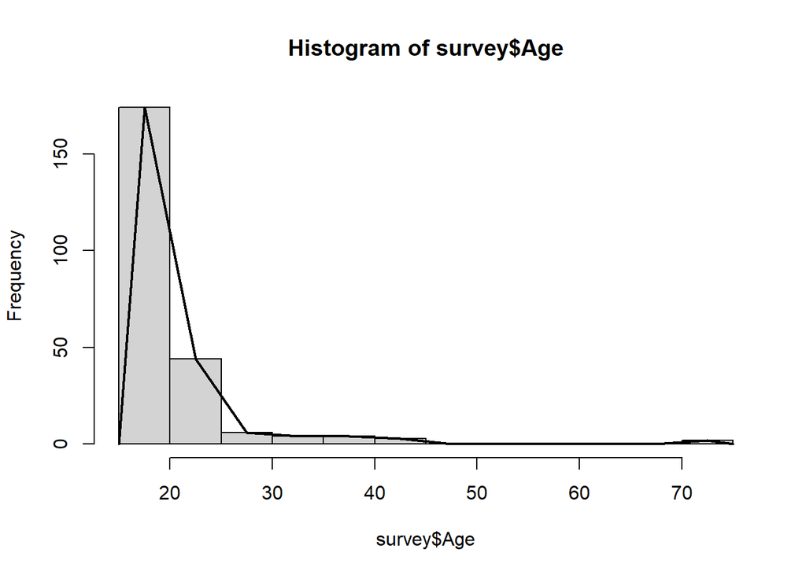

```r
> hist(survey$Age)
> lines(x = c(min(h$breaks), h$mids, max(h$breaks)),
+       y = c(0, h$counts, 0),
+       type = "l",
+       lwd = 2)
```

Another way is to use the function `simple.freqpoly` from the package `UsingR`

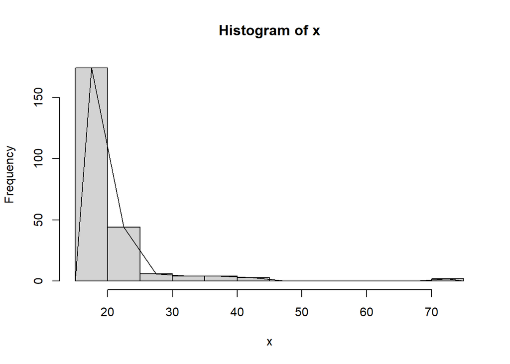

```r
> simple.freqpoly(survey$Age)
```

The idea of the polygon is to give you an overall idea of the data distribution, so you can tie it up with the probability density of the parent population

### Densities

`density` gives more sophisticated presentation of the data distribution. The basic idea is for each point to take some kind of an average for the points nearby and based on this to give an estimate for the density.

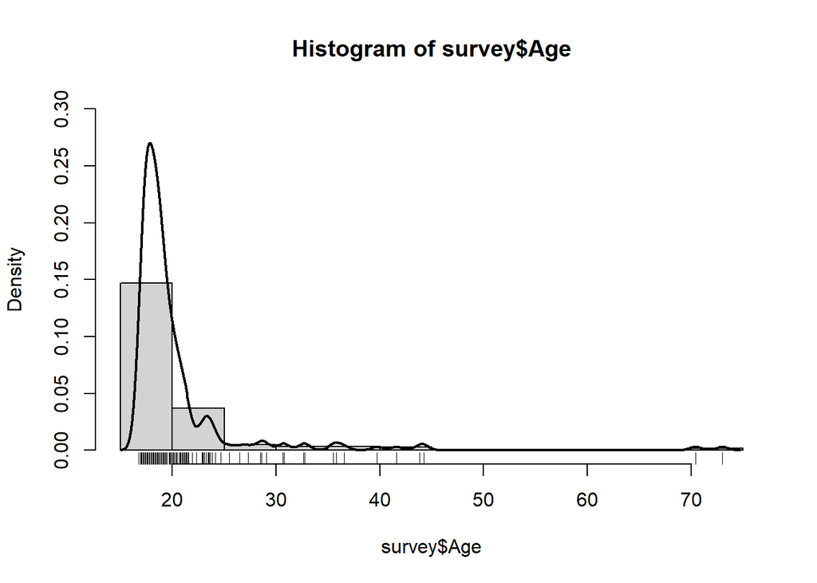

```r
> density(survey$Age)

Call:
    density.default(x = survey$Age)

Data: survey$Age (237 obs.);    Bandwidth 'bw' = 0.5625

       x               y
 Min.   :15.06   Min.   :0.000000
 1st Qu.:29.97   1st Qu.:0.000000
 Median :44.88   Median :0.001214
 Mean   :44.88   Mean   :0.016753
 3rd Qu.:59.78   3rd Qu.:0.004858
 Max.   :74.69   Max.   :0.270452
> hist(survey$Age, probability = TRUE, ylim = c(0, 0.3))
> rug(survey$Age)
> lines(density(survey$Age), lwd = 2)
```

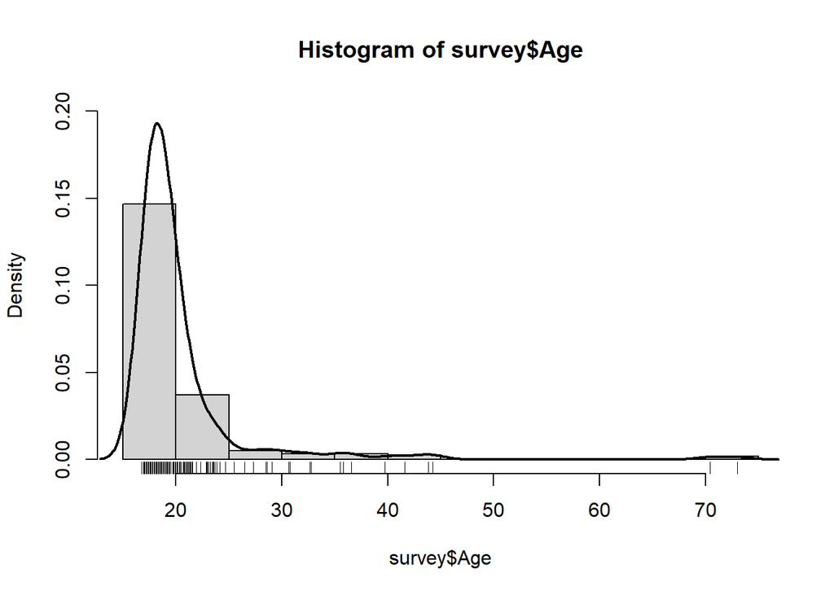

```r
> density(survey$Age, bw = 1.3)

Call:
    density.default(x = survey$Age, bw = 1.3)

Data: survey$Age (237 obs.);    Bandwidth 'bw' = 1.3

       x               y
 Min.   :12.85   Min.   :0.000e+00
 1st Qu.:28.86   1st Qu.:8.100e-07
 Median :44.88   Median :1.581e-03
 Mean   :44.88   Mean   :1.560e-02
 3rd Qu.:60.89   3rd Qu.:4.986e-03
 Max.   :76.90   Max.   :1.934e-01
> hist(survey$Age, probability = TRUE, ylim = c(0, 0.2))
> rug(survey$Age)
> lines(density(survey$Age, bw = 1.3), lwd = 2)
```

If the bandwidth is too small, the result is too jagged, and if it is too big the result is too smooth

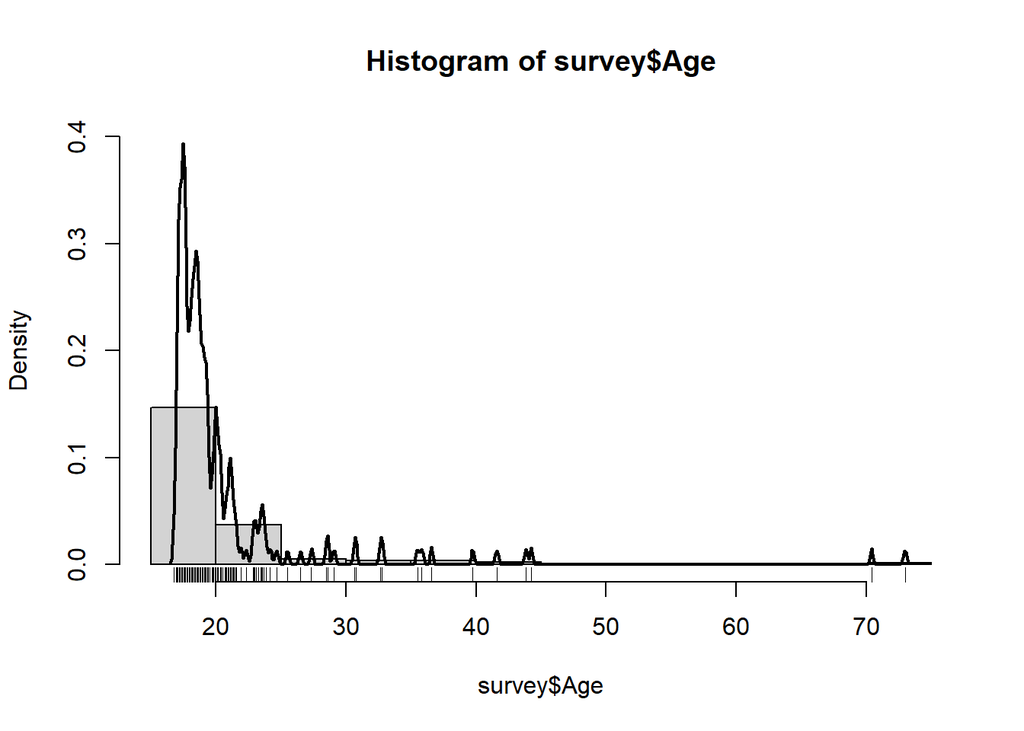

```r
> density(survey$Age, bw = 0.1)

Call:
    density.default(x = survey$Age, bw = 0.1)

Data: survey$Age (237 obs.);    Bandwidth 'bw' = 0.1

       x               y
 Min.   :16.45   Min.   :0.000000
 1st Qu.:30.66   1st Qu.:0.000000
 Median :44.88   Median :0.000000
 Mean   :44.88   Mean   :0.017571
 3rd Qu.:59.09   3rd Qu.:0.004739
 Max.   :73.30   Max.   :0.393992
> hist(survey$Age, probability = TRUE, ylim = c(0, 0.4))
> rug(survey$Age)
> lines(density(survey$Age, bw = 0.1), lwd = 2)
```

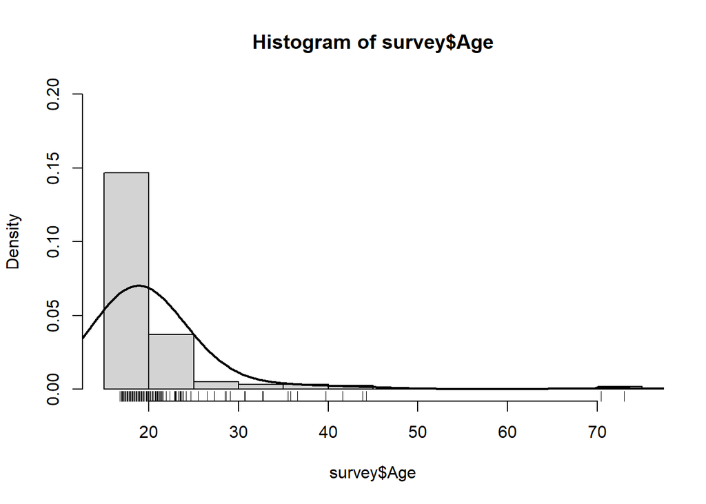

```r
> density(survey$Age, bw = 5)

Call:
    density.default(x = survey$Age, bw = 5)

Data: survey$Age (237 obs.);    Bandwidth 'bw' = 5

       x               y
 Min.   : 1.75   Min.   :4.490e-06
 1st Qu.:23.31   1st Qu.:2.491e-04
 Median :44.88   Median :9.966e-04
 Mean   :44.88   Mean   :1.158e-02
 3rd Qu.:66.44   3rd Qu.:1.056e-02
 Max.   :88.00   Max.   :7.021e-02
> hist(survey$Age, probability = TRUE, ylim = c(0, 0.2))
> rug(survey$Age)
> lines(density(survey$Age, bw = 5), lwd = 2)
```